# Using Models 1

Rozy Bathrick

### Q1 Create a histogram of the salamander reproduction catastrophic rates

```r
require(here)
catrate<-read.csv(here("data", "catrate.csv"))
head(catrate)
```

|  | pond | success | years | cat.rate |
| --- | --- | --- | --- | --- |
| 1 | 2 | 5 | 7 | 0.2857143 |
| 2 | 3 | 5 | 7 | 0.2857143 |
| 3 | 4 | 6 | 7 | 0.1428571 |
| 4 | 5 | 4 | 7 | 0.4285714 |
| 5 | 6 | 0 | 7 | 1.0000000 |
| 6 | 7 | 1 | 4 | 0.7500000 |

```r
summary(catrate)
```

```
##       pond       success          years          cat.rate
##  Min.   : 2   Min.   :0.000   Min.   :1.000   Min.   :0.1429
##  1st Qu.: 5   1st Qu.:1.000   1st Qu.:3.000   1st Qu.:0.2857
##  Median : 8   Median :2.000   Median :4.000   Median :0.4286
##  Mean   : 8   Mean   :2.538   Mean   :4.692   Mean   :0.5394
##  3rd Qu.:11   3rd Qu.:5.000   3rd Qu.:7.000   3rd Qu.:0.7500
##  Max.   :14   Max.   :6.000   Max.   :7.000   Max.   :1.0000
```

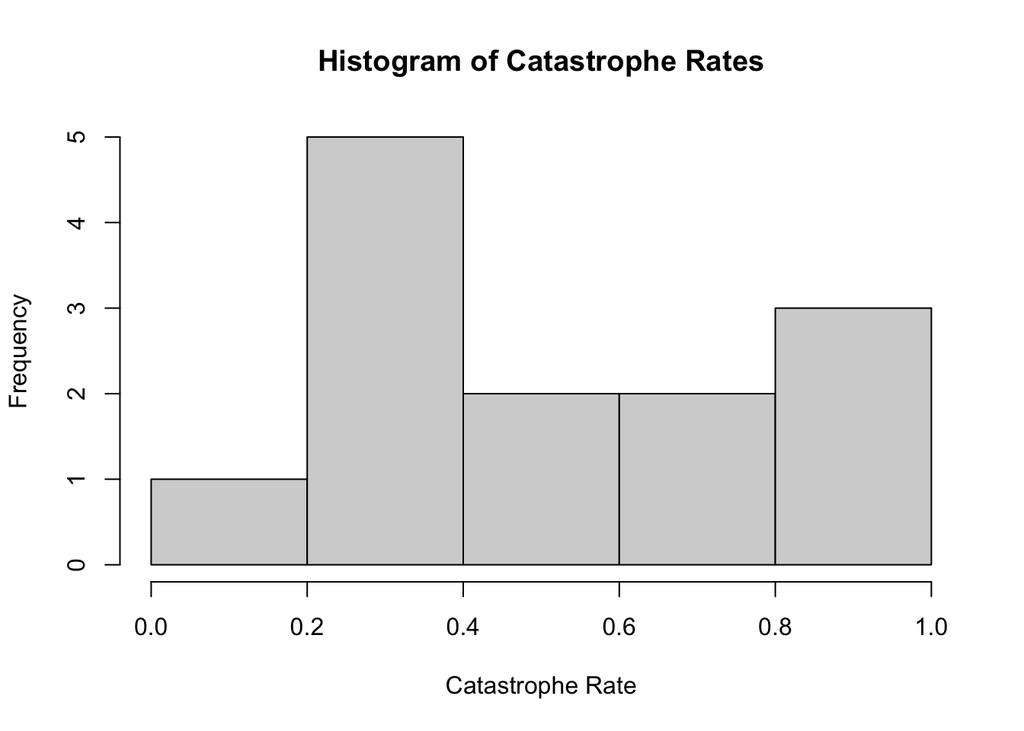

```r
hist(catrate$cat.rate, xlab="Catastrophe Rate", main="Histogram of Catastrophe Rates")
```

### Q2 Conduct a Shapiro-Wilk test of normality of the salamander catastrophic rates. Report the p-value and show the R-code you used to conduct the test.

```r
shapiro.test(catrate$cat.rate)
```

```
##
##  Shapiro-Wilk normality test
##
## data:  catrate$cat.rate
## W = 0.86202, p-value = 0.04097
```

### Q3 (1 pt.): What is the null hypothesis for the Shapiro test?

A: The null hypothesis is the data was sampled from a normally-distributed population

### Q4 (1 pt.): Based on the Shapiro test results, is there strong evidence that the sample came from a non-normally-distributed population?

A: The p-value is smaller than 0.05, thus we have evidence that we can reject the null - the sample came from a non-normally distributed population

### Q5 (1 pt.): Show the code you used to conduct the t-test.

```r
t.test(catrate$cat.rate, mu=2/7)
```

```
##
##  One Sample t-test
##
## data:  catrate$cat.rate
## t = 2.9595, df = 12, p-value = 0.01193
## alternative hypothesis: true mean is not equal to 0.2857143
## 95 percent confidence interval:
##  0.3526250 0.7261295
## sample estimates:
## mean of x
## 0.5393773
```

### Q6 (1 pt.): State the null hypothesis of the test, in plain nontechnical English.

A: The null hypothesis is that the observed catastrophic rate is not different from the observed late-filling rate

### Q7 (1 pt.): Is this a one- or two-tailed test?

A: It is a two-tailed test

### Q8 (2 pts.): What is the p-value from your t-test? Interpret the p-value as a false-positive rate using nontechnical English that a non-scientist would understand.

A: The p-value is 0.01193, which means that we can reject the null that there is no difference between the two means. But - that doesn’t mean the difference is solely about the late-filling pond rate, because the cat.rate includes other types of catastrophes.

### Q11 (1 pt.): Show the code you used to conduct the test.

```r
wilcox.test(catrate$cat.rate, mu = 2 / 7)
```

```
##
##  Wilcoxon signed rank test with continuity correction
##
## data:  catrate$cat.rate
## V = 85, p-value = 0.006275
## alternative hypothesis: true location is not equal to 0.2857143
```

### Q12 (1 pt.): Compare the p-value with the p-value you got from the t-test.

The t.test p-value is 0.01193, the Wilcoxon p-value is smaller at 0.006275

### Q13 (2 pts.): Considering the results from your rank sum test, did you conclude that there was strong evidence to reject the null hypothesis?

Yes, there is strong evidence.

### Q16 (2 pts.): Show the R-code you used to conduct tests of normality for the flipper lengths of Chinstrap and Adelie penguins.

```r
require(palmerpenguins)
penguin_dat = droplevels(subset(penguins, species != "Gentoo"))
summary(penguin_dat)
```

```
##       species          island    bill_length_mm  bill_depth_mm
##  Adelie   :152   Biscoe   : 44   Min.   :32.10   Min.   :15.50
##  Chinstrap: 68   Dream    :124   1st Qu.:37.75   1st Qu.:17.50
##                  Torgersen: 52   Median :40.60   Median :18.40
##                                  Mean   :41.91   Mean   :18.37
##                                  3rd Qu.:45.95   3rd Qu.:19.10
##                                  Max.   :58.00   Max.   :21.50
##                                  NA's   :1       NA's   :1
##  flipper_length_mm  body_mass_g       sex           year
##  Min.   :172.0     Min.   :2700   female:107   Min.   :2007
##  1st Qu.:187.0     1st Qu.:3400   male  :107   1st Qu.:2007
##  Median :191.0     Median :3700   NA's  :  6   Median :2008
##  Mean   :191.8     Mean   :3711                Mean   :2008
##  3rd Qu.:196.0     3rd Qu.:3988                3rd Qu.:2009
##  Max.   :212.0     Max.   :4800                Max.   :2009
##  NA's   :1         NA's   :1
```

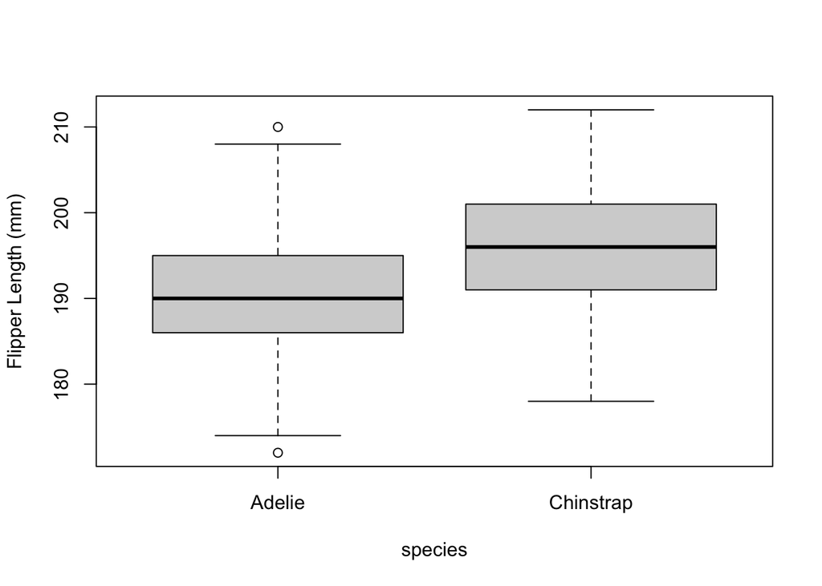

```r
boxplot(
  flipper_length_mm ~ species,
  data = penguin_dat,
  ylab = "Flipper Length (mm)")
```

```r
dat_adelie = subset(penguin_dat, species == "Adelie")
dat_gentoo=subset(penguin_dat, species == "Gentoo")
dat_chin=subset(penguin_dat, species == "Chinstrap")
dat_adchin=subset(penguin_dat, species=c("Adelie", "Chinstrap"))
shapiro.test(dat_adelie$flipper_length_mm)
```

```
##
##  Shapiro-Wilk normality test
##
## data:  dat_adelie$flipper_length_mm
## W = 0.99339, p-value = 0.72
```

```r
shapiro.test(dat_chin$flipper_length_mm)
```

```
##
##  Shapiro-Wilk normality test
##
## data:  dat_chin$flipper_length_mm
## W = 0.98891, p-value = 0.8106
```

### Q17 (2 pts.): Interpret the test results. Do you conclude that the flipper lengths are normally-distributed for each species? Make sure your answers make reference to the test output.

A: Adelie flipper lengths do appear to be normally distributed (p=0.72), we accept the null. Chinstrap flipper lengths also appear to be normally distributed (p=0.8106), accept the null

### Q18 (2 pts.): Save your figure to a file and include it in your report. Your figure needs to have appropriate dimensions such that the two histograms are not vertically stretched.

Hint: Check out the width and height arguments. Hint: Remember the par() function? Which argument did we use to include multiple plots in the same figure?

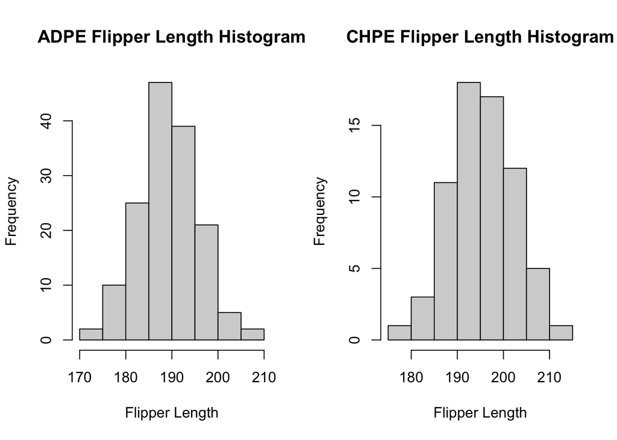

```r
par(mfrow=c(1,2))
hist(dat_adelie$flipper_length_mm, xlab="Flipper Length", main="ADPE Flipper Length Histogram")
hist(dat_chin$flipper_length_mm, xlab="Flipper Length", main="CHPE Flipper Length Histogram")
```

### Q19 (2 pts.): State the alternative hypothesis of the test, in plain nontechnical English.Consider whether you used a one- or two- tailed test.

A: The alternative hypothesis is that Adelie Penguin have different flipper length than Chinstrap (they are either bigger or smaller) - it is a 2-tailed test

### Q20 (1 pt.): Include the code you used to conduct the t-test.Hint: your answer should only be a single line of code.

```r
t.test(flipper_length_mm~species, data=dat_adchin)
```

```
##
##  Welch Two Sample t-test
##
## data:  flipper_length_mm by species
## t = -5.7804, df = 119.68, p-value = 6.049e-08
## alternative hypothesis: true difference in means is not equal to 0
## 95 percent confidence interval:
##  -7.880530 -3.859244
## sample estimates:
##    mean in group Adelie mean in group Chinstrap
##                189.9536                195.8235
```